# Project - Module 8 (Exercise Quality Project)

John J. Como, MD, MPH

2025-04-14

```
## setwd("C:/Users/user/Dropbox/Education/Coursera/JH Data Science/PRACTICAL MACHINE LEARNING")
rmarkdown::render("C:/Users/user/Dropbox/Education/Coursera/JH Data Science/PRACTICAL MACHINE LEARNING/Project_8.Rmd", output_dir = "output")
knitr::opts_chunk$set(echo = TRUE)
```

One thing that people regularly do is to quantify how much of a particular activity they do, but they rarely qualify how well they do it. In this project, the goal was to use data from accelerometers on the belt, forearm, arm, and dumbell of six participants to investigate the quality of their exercise.

The goal of this project was to predict the manner in which the participants did the exercise. This was the “classe” variable in the training set.

We were asked to create a report describing how this model was built, how cross validation was used, what we thought the expected out of sample error was, and why we made the choices we did.

We were also asked to use our prediction model to predict 20 different test cases.

### *READING DATA INTO R - BOTH TRAINING AND TESTING SETS*

First, the data were read into R.

```r
## setwd("C:/Users/user/Dropbox/Education/Coursera/JH Data Science/PRACTICAL MACHINE LEARNING")
training<-read.csv("pml-training.csv", na.strings = c("#DIV/0!", ".", "NA"))
dim(training)
```

```
## [1] 19622   160
```

```r
testing<-read.csv("pml-testing.csv", na.strings = c("#DIV/0!", ".", "NA"))
dim(testing)
```

```
## [1]  20 160
```

### *RESTRICTING THE VARIABLES TO SENSOR-RELATED ONES*

The data in the first seven columns are not sensor readings. The data from these columns were removed from the data base.

```r
sensorColumns <- grep(pattern = "_belt|_arm|_dumbbell|_forearm", names(training))
length(sensorColumns)
```

```
## [1] 152
```

```r
data <- training[ , c(sensorColumns, 160)]
dim(data)
```

```
## [1] 19622   153
```

### *HANDLING NA VALUES*

Our next goal was to select and remove sensor data columns whose values were NA for almost all observations. We also checked that there were no more data frames still with missing values.

```r
missingData <- is.na(data)
omitColumns <- which(colSums(missingData) > 19000)
data <- data[ , -omitColumns]
dim(data)
```

```
## [1] 19622    53
```

```r
table(complete.cases(data))
```

```
##
##  TRUE
## 19622
```

```r
table(sapply(data[1,],class))
```

```
##
## character   integer   numeric
##         1        25        27
```

### *DATA SPLITTING AND DISCUSSION OF PREPROCESSING*

We then split our data into training (75% of cases) and testing set (the remaining cases). We then estimated the out of sample error of our predictor.

```r
set.seed(2014)
library(caret)
inTrain<-createDataPartition(training$classe, p=3/4, list = FALSE)
training <- data[inTrain, ]
testing <- data[-inTrain, ]
dim(training)
```

```
## [1] 14718    53
```

```r
dim(testing)
```

```
## [1] 4904   53
```

### *TRAINING THE PREDICTOR*

We then used the randomForest function (from the randomForest package) to fit the predictor to the training The number of trees (n = 500) gives a reasonable trade off between training time and accuracy. In more powerful machines, this number can be increased to obtain slightly better predictions.

```r
library(randomForest)
training$classe <- as.factor(training$classe)
time1 <- proc.time() ## Start the timer
randForest <- randomForest(classe ~ ., data = training, ntree = 500) ## Train the model
time2 <- proc.time() ## Stop the timer
time <- time2 - time1
print(time) ## Elapsed time
```

```
##    user  system elapsed
##   36.55    0.31   37.15
```

### APPLYING THE MODEL TO THE TESTING SUBSAMPLE

Now that we have trained the predictor, we may use it on the testing subsample that we had created before to get a estimate of its out of sample error.

The confusion matrix, which compares predicted versus actual cases (A to E) revealed an accuracy of 0.9951 (99.51% correct predictions), with almost all misclassifications being minor and localized, suggesting a very high-quality model. The very low p value suggests that our model performs significantly better than random chance.

```r
predictionTesting <- predict(randForest, newdata = testing)
predictionTesting <- factor(predictionTesting, levels = levels(training$classe))
testing$classe <- factor(testing$classe, levels = levels(training$classe))
confusionMatrix(predictionTesting, testing$classe)
```

```
## Confusion Matrix and Statistics
##
##           Reference
## Prediction    A    B    C    D    E
##          A 1395    5    0    0    0
##          B    0  943    5    0    0
##          C    0    1  850   10    0
##          D    0    0    0  793    2
##          E    0    0    0    1  899
##
## Overall Statistics
##
##                Accuracy : 0.9951
##                  95% CI : (0.9927, 0.9969)
##     No Information Rate : 0.2845
##     P-Value [Acc > NIR] : < 2.2e-16
##
##                   Kappa : 0.9938
##
##  Mcnemar's Test P-Value : NA
##
## Statistics by Class:
##
##                      Class: A Class: B Class: C Class: D Class: E
## Sensitivity            1.0000   0.9937   0.9942   0.9863   0.9978
## Specificity            0.9986   0.9987   0.9973   0.9995   0.9998
## Pos Pred Value         0.9964   0.9947   0.9872   0.9975   0.9989
## Neg Pred Value         1.0000   0.9985   0.9988   0.9973   0.9995
## Prevalence             0.2845   0.1935   0.1743   0.1639   0.1837
## Detection Rate         0.2845   0.1923   0.1733   0.1617   0.1833
## Detection Prevalence   0.2855   0.1933   0.1756   0.1621   0.1835
## Balanced Accuracy      0.9993   0.9962   0.9957   0.9929   0.9988
```

Below is a variable importance plot for a random forest model, using the MeanDecreaseGini metric.

The X-axis (MeanDecreaseGini) tells us how much each variable contributes to reducing model impurity in a random forest. The higher the value, the more important the variable is.

On the Y-axis are the predictor variables, the sensor measurements in this case.

The individual data points represent the importance of each variable based on its average contribution across all trees in the forest.

The roll_belt, the yaw_belt, and the pitch_forearm, in that order, were the top three features. As they had the largest average decrease in Gini impurity, they were the most helpful for the model in distinguishing between classes.

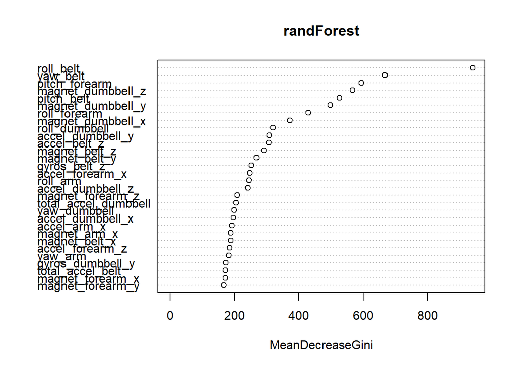

```r
varImpPlot(randForest)
```